# Lecture 101

2021-09-11

## Introduction to R

## About this module

This module will provide you with the fundamental skills in

- basic programming in R
- data wrangling
- data analysis
- reproducibility

basis for

- *Geospatial Data Analysis*
- *Geospatial Databases and Information Retrieval*

## R programming language

One of the most widely used programming languages and an effective tool for *(geospatial)* data science

- data wrangling
- statistical analysis
- machine learning
- data visualisation and maps
- processing spatial data
- geographic information analysis

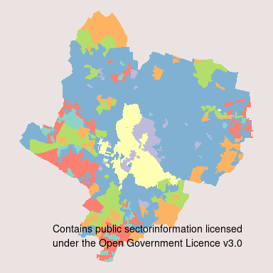

## Schedule

The lectures and practical sessions have been designed to follow the schedule below

- **1 R coding**
  - 100 Introduction
  - 110 R programming
- **2 Data wrangling**
  - 200 Selection and manipulation
  - 210 Table operations
  - 220 Reproducibility
- **3 Data analysis**
  - 300 Exploratory data analysis
  - 310 Comparing data
  - 320 Regression models
- **4 Machine learning**
  - 400 Unsupervised
  - 410 Supervised

## Reference books

Suggested reading

- *Programming Skills for Data Science: Start Writing Code to Wrangle, Analyze, and Visualize Data with R* by Michael Freeman and Joel Ross, Addison-Wesley, 2019. See book [webpage](https://www.pearson.com/us/higher-education/program/Freeman-Programming-Skills-for-Data-Science-Start-Writing-Code-to-Wrangle-Analyze-and-Visualize-Data-with-R/PGM2047488.html) and [repository](https://programming-for-data-science.github.io/).
- *R for Data Science* by Garrett Grolemund and Hadley Wickham, O’Reilly Media, 2016. See [online book](https://r4ds.had.co.nz/).
- *Discovering Statistics Using R* by Andy Field, Jeremy Miles and Zoë Field, SAGE Publications Ltd, 2012. See book [webpage](https://www.discoveringstatistics.com/books/discovering-statistics-using-r/).
- *Machine Learning with R: Expert techniques for predictive modeling* by Brett Lantz, Packt Publishing, 2019. See book [webpage](https://subscription.packtpub.com/book/big_data_and_business_intelligence/9781788295864).

Further reading

- *The Art of R Programming: A Tour of Statistical Software Design* by Norman Matloff, No Starch Press, 2011. See book [webpage](https://nostarch.com/artofr.htm)
- *An Introduction to R for Spatial Analysis and Mapping* by Chris Brunsdon and Lex Comber, Sage, 2015. See book [webpage](https://uk.sagepub.com/en-gb/eur/an-introduction-to-r-for-spatial-analysis-and-mapping/book241031)
- *Geocomputation with R* by Robin Lovelace, Jakub Nowosad, Jannes Muenchow, CRC Press, 2019. See [online book](https://bookdown.org/robinlovelace/geocompr/).

## R

Created in 1992 by Ross Ihaka and Robert Gentleman at the University of Auckland, New Zealand

- Free, open-source implementation of *S*
  - statistical programming language
  - Bell Labs
- Functional programming language
- Supports (and commonly used as) procedural (i.e., imperative) programming
- Object-oriented
- Interpreted (not compiled)

## Interpreting values

When values and operations are inputted in the *Console*, the interpreter returns the results of its interpretation of the expression

```r
2
```

```
## [1] 2
```

```r
"String value"
```

```
## [1] "String value"
```

```r
# comments are ignored
```

## Basic types

R provides three core data types

- numeric
  - both integer and real numbers
- character
  - i.e., text, also called *strings*
- logical
  - `TRUE` or `FALSE`

## Numeric operators

R provides a series of basic numeric operators

| Operator | Meaning | Example | Output |
| --- | --- | --- | --- |
| + | Plus | `5 + 2` | 7 |
| - | Minus | `5 - 2` | 3 |
| `*` | Product | `5 * 2` | 10 |
| / | Division | `5 / 2` | 2.5 |
| %/% | Integer division | `5 %/% 2` | 2 |
| %% | Module | `5 %% 2` | 1 |
| ^ | Power | `5^2` | 25 |

```r
5 + 2
```

```
## [1] 7
```

## Logical operators

R provides a series of basic logical operators to test

| Operator | Meaning | Example | Output |
| --- | --- | --- | --- |
| == | Equal | `5 == 2` | FALSE |
| != | Not equal | `5 != 2` | TRUE |
| > (>=) | Greater (or equal) | `5 > 2` | TRUE |
| < (<=) | Less (or equal) | `5 <= 2` | FALSE |
| ! | Not | `!TRUE` | FALSE |
| & | And | `TRUE & FALSE` | FALSE |
| \| | Or | `TRUE \| FALSE` | TRUE |

```r
5 >= 2
```

```
## [1] TRUE
```

## Summary

An introduction to R

- Basic types
- Basic operators

**Next**: Core concepts

- Variables
- Functions
- Libraries